# Predicting Yearly Salary for NBA Players: 1990-2017

Final Project  
Data Science 2 with R (STAT 301-2)

Author

Ignacio Dowling

Published

March 13, 2024

**Github Repo Link**

https://github.com/stat301-2-2024-winter/final-project-2-idowling11

## Introduction

I created a model that predicts an NBA player’s yearly salary based on their age, team, role, season, and the dozens of other season statistics in my dataset (described below). Ultimately, I looked to determine an NBA player’s “deserved” salary based on the various factors and statistics listed in that set, which is a regression problem. The variable I’m trying to predict is player_salary_in, which I renamed to player_salary. To do so, I log-10-transformed that target variable, as described in further detail in the data overview section.

The data comes from a Kaggle dataset of National Basketball Association individual player statistics and salary data from 1950 to 2017. I am using the “Basic Season - Season Stats” sheet.[^1] As stated above, my outcome variable is player_salary_in.

<sup>1</sup> Here is a — [link to that](https://www.kaggle.com/datasets/whitefero/nba-players-advanced-season-stats-19782016) to the Kaggle page with the dataset.

As I cleaned the dataset, I modified the columns and adjusted for missingness, leaving me with 10,852 observations, 50 numeric variables and three categorical ones.

I’m interested in the NBA, and thought this would be fun. Fans constantly bicker about different players’ values, especially ones that are considered overpaid and ones that are underpaid. Finding a diamond in the rough (or vice versa) greatly impacts roster construction, which of course impacts game results. A prediction model would take much more into account beyond comparing a salary amount to other players in the league at a given time, and would give someone a much better idea of whether a player met their contract demands in a given year.

## Data Overview

### Examining Missingness for Raw Dataset

Here is a look at the missingness for the raw dataset in Table 1, with a very small amount of cleaning for the variable names. I only included variables with more than 5% missingness; those not included (29 of the 54) have less than 5% missingness.

Table 1: Examining Variable Missingness in Raw NBA Dataset

| Variable Name | Number of Observations Missing | Rate of Observations Not Missing |
| --- | --- | --- |
| blanl | 24625 | 0.0000000 |
| blank2 | 24625 | 0.0000000 |
| player_salary | 13648 | 0.4457665 |
| x3p_percent | 9209 | 0.6260305 |
| gs | 6392 | 0.7404264 |
| x3p_ar | 5786 | 0.7650355 |
| x3p | 5698 | 0.7686091 |
| x3pa | 5698 | 0.7686091 |
| tov_percent | 5043 | 0.7952081 |
| usg_percent | 4985 | 0.7975635 |
| tov | 4980 | 0.7977665 |
| orb_percent | 3833 | 0.8443452 |
| drb_percent | 3833 | 0.8443452 |
| stl_percent | 3833 | 0.8443452 |
| blk_percent | 3833 | 0.8443452 |
| obpm | 3828 | 0.8445482 |
| dbpm | 3828 | 0.8445482 |
| bpm | 3828 | 0.8445482 |
| vorp | 3828 | 0.8445482 |
| orb | 3828 | 0.8445482 |
| drb | 3828 | 0.8445482 |
| stl | 3828 | 0.8445482 |
| blk | 3828 | 0.8445482 |
| trb_percent | 3054 | 0.8759797 |
| ast_percent | 2070 | 0.9159391 |

Obviously, there’s some missingness, though the only thing massive here is that of the target variable, which I’ll expand on in the following section. Even x3p_percent, which records the three-point percentage of different players, isn’t especially bad missingness since the NBA’s three-point line wasn’t invented until 1979, 29 years after the earliest recorded observation in this dataset. Let’s dive into the target variable, though:

### Examining Missingness for Target Variable and Cleaned Dataset

Table 2 displays what the missingness and distribution of the target variable in the dataset looked like after very preliminary cleaning (i.e. cleaning variable names):

Table 2: Examining Original Salary Variable Missingness

| Number of Observations Missing | Rate of Observations Not Missing |
| --- | --- |
| 13648 | 0.4457665 |

It’s clear that there’s significant missingness in the original dataset for salary; over 55% of the observations do not include a player’s salary. After some further exploration and cleaning, I identified that this was because salaries for seasons before 1990 were not recorded in this dataset. Thus, in cleaning the dataset (those steps can be found in the R Scripts folder), I filtered those out to only explore observations with seasons 1990 or later. After doing so, Table 3 shows what the missingness looked like:

Table 3: Examining Salary Variable Missingness for 1990-2017

| Number of Observations Missing | Rate of Observations Not Missing |
| --- | --- |
| 0 | 1 |

Perfect! No missingness at all. However, what is of note is that there were NA values in the original dataset for some shooting percentage variables. For players who had not taken a certain type of shot, their percentage for that attempt category led to a “divide by 0” situation, which brought about an NA. I replaced those NAs with 0s in the cleaning, given those players had not taken a single shot (not exactly, but essentially shooting 0%).

Now let’s take a look at potential categorical imbalance after cleaning the dataset:

### Examining Categorical Data Balance

The three categorical variables here are player names, player positions, and player teams. The former is obviously balanced with thousands of different values, as there have been thousands of different NBA players since 1990.

Let’s start with distribution of different basketball player positions in Table 4:

Table 4: Examining Basketball Position Frequency for 1990-2017

| Position | Frequency |
| --- | --- |
| PF | 2341 |
| PG | 2197 |
| C | 2195 |
| SG | 2099 |
| SF | 2020 |

The five primary positions – power forward (PF), point guard (PG), center (C), shooting guard (SG), and small forward (SF) – all appear to be reasonably balanced when it comes to frequency.

There were a few hybrids of very small frequency (i.e. point guard/small forwards, etc., fewer than 20), which I cut in the cleaning to evaluate the five actual positions.

Let’s look at teams, our other variable, in Table 5.

Table 5: Examining Basketball Team Frequency for 1990-2017

| Team Name | Frequency |
| --- | --- |
| TOT | 764 |
| CLE | 370 |
| MIL | 367 |
| ATL | 361 |
| GSW | 360 |
| DAL | 359 |
| SAC | 357 |
| BOS | 355 |
| POR | 355 |
| LAC | 354 |
| DEN | 350 |
| ORL | 349 |
| CHI | 342 |
| HOU | 339 |
| UTA | 338 |
| MIN | 337 |
| NYK | 337 |
| PHO | 334 |
| LAL | 329 |
| DET | 327 |
| MIA | 326 |
| PHI | 324 |
| SAS | 322 |
| IND | 310 |
| TOR | 294 |
| NJN | 285 |
| WAS | 271 |
| SEA | 247 |
| MEM | 238 |
| CHH | 151 |
| OKC | 133 |
| NOH | 120 |
| WSB | 102 |
| BRK | 72 |
| VAN | 72 |
| NOP | 69 |
| CHA | 64 |
| CHO | 42 |
| NOK | 26 |

Likewise, this appears to be somewhat balanced, especially for there being around 35 levels. However, there’s some slight imbalance here. For that, and for reasons I’ll expand on in the EDA appendix, I won’t include it in my feature-engineered recipe.

## Exploring the Target Variable

Let’s start with a univariate analysis, and look at Figure 1’s display of salaries in the NBA from 1990-2017:

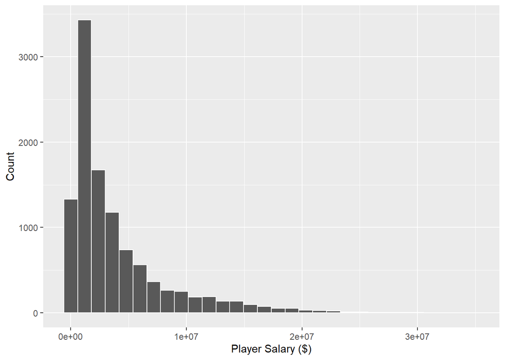

Figure 1: Distribution of NBA Salaries: 1990-2017

The data is heavily right-skewed, with most players making less than $5 million in a year. It makes sense; most players aren’t elite, and therefore the vast majority of players do not make anywhere near as much money as the most elite stars. With 15 players to pay and 5 players on a court at once (allowing for more individual impact than in other team sports), often one or two players on a team make more or as much as multiple other ones combined.

To combat that skew, it’d be helpful to log-transform this data to reduce this skewness and make the distribution more normal. Thus, I applied a log-10 transformation to the variable. Here’s what the new distribution looked like in Figure 2:

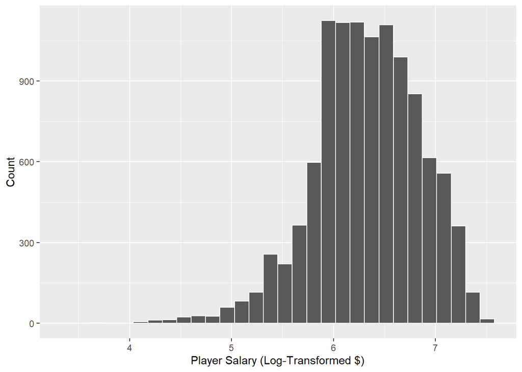

Figure 2: Distribution of NBA Salaries (log-transformed): 1990-2017

While not perfect (there appears to be a slight left skew), this distribution is much closer to normal than the first one. On this scale, most players fall in between roughly 5.7 and 6.7 here, which is still a lot of money relative to the average person.

Below are some additional statistics for the log-transformed variable in Table 6:

Table 6: Log-10 Salary Summary Statistics

| variable | mean | sd | min | median | max |
| --- | --- | --- | --- | --- | --- |
| log_10_player_salary | 6.324731 | 0.5241354 | 3.432328 | 6.33912 | 7.540111 |

As stated above, the minimum value is relatively high, well over 3 here. The mean and median are somewhat close to another, as well, while the max is a little more than 2 standard deviations from the median of $6.34 (log-transformed).

Further relationships of the predictors (and ensuing transformations) with the log-transformed target variable of salary can be found in the EDA Appendix.

## Methods

### Data Splitting

This is a regression problem. To begin, I split my cleaned dataset of 10,852 observations into training and testing data. Approximately 80% of the dataset – or 8,679 observations were a part of the training set, while the other 20% – or the other 2,173 observations – went into the testing set. I also used 50% of the training dataset (4,339 observations) for EDA.

### Model Types

I will fit six different model types, each with two recipes, making for 12 models total.

The first is my baseline model: a **null** one. It is very simple, and has no arguments. The second is an **ordinary linear regression** model; each of its predictors will have coefficients to make a salary estimation. It uses least squares to identify model parameters.

The next two model types are tree-based ones, or ones that use decision trees to determine the impact of different variables in predicting the target variable: **random forest** and **boosted tree**. The random forest model splits predictor data into different sub-sections, in which the ensuing predictions use each sub-section’s average or mode for a respective predictor variable.

The boosted tree ones will put together ordinary regression decision trees after each are trained on residuals, weighting each by using an additive model. In other words, each successive decision tree “learns” from the errors of previous ones to improve the strength of the model.

The final two model types are my **elastic net** and **K-nearest neighbor models.** The elastic net is a combination of lasso and ridge models, meaning that it uses penalty terms from both the of the aforementioned types to impact its regression predictions. The K-nearest neighbor models will pick a certain number of variables to predict log-transformed salary, and then identify the squared distance between each new data point’s feature and each training point’s feature before adding them up.

I did use KNN on the tree-based recipe, even though it’s non-parametric, given its similarities to the random forest model in which transformations and interactions could add unneccessary noise that could worsen the model.

### Tuning parameters

For the random forest model, I will tune the **mtry** (updating based on the number of predictor columns after each recipe) and **min_n** parameters while setting the number of trees to 1,000 – large enough for reliability. The min_n parameter is the minimum number of data points required for the model to split into each certain sub-section, or region. The mtry parameter represents the range of the number of randomly sampled predictors.

For the boosted tree models, I tuned the same parameters, but also tuned **learn_rate**, which measures the amount of influence each successive tree has compared to the previous ones on a scale of 0 to 1 (with 1 being the strongest effect). As for elastic net, I tuned the parameters **penalty** and **mixture**. Penalty determines how much regularization will be used to reduce overfitting, while mixture identifies how much of the lasso penalty will be applied on a range of 0 (no penalty, relying on a ridge regression model) to 1 (a full lasso model).

Finally, I am tuning the **neighbors** parameter for my knn model. It, also known as K, measures the number of nearest neighbors to measure squared distances for at each data point.

### Resampling and Recipes

I will be using repeated V-fold cross-validation in this project: 5 folds and 3 repeats to randomly split the data into 5 equal-sized sets, with different performance metrics for each. That process will be repeated thrice.

As for the recipes, I made two kitchen sink ones (where I included essentially every predictor) and two feature-engineered ones (where I removed some predictors, added interactions, and added general complexity). The difference between each pair was that one of each category was for tree-based models (i.e. one feature-engineered tree-based model, one kitchen sink tree-based one) and one was for non-parametric models. The primary difference between the non-parametric and parametric kitchen sink recipes were that I one-hot encoded the categorical variables I was including as predictors.

That difference existed for the feature-engineered ones, though another primary difference was that the feature-engineered tree-based recipe did NOT include interactions, transformations, and splines, while the non-parametric one did.

For the kitchen sink recipe, I left the steps as simple as I could while adding some basic steps of complexity in order to make the model run. With thousands of different player names, I removed that categorical variable using step_rm() for computational efficiency and because it was an ID variable. I also removed the non-transformed player salary variable since it was a target variable that I had transformed already. From there, to make the model run, I used step_lincomb() since I had a number of predictors that directly related to each other (i.e. offensive win shares, defensive win shares, and total win shares; field goals attempted, field goals made, and field goals percentage), so I just wanted to ensure the recipe would run smoothly without potentially fatal linear combinations.

Additionally, I used step_novel() since the team variable had around 35 factor levels (leaving a chance that there’d be a new level appearing, so wanted to use it just in case), and then used step_dummy() to make sure my categorical variable data would be stored in a binary way for the models to run. From there, I added steps to filter out zero-variance and near-zero variance to eliminate potential imbalance, before normalizing all of my predictors to cap it off.

In prepping and baking the kitchen sink recipe, I noticed that the near-zero variance filter step had filtered out essentially all of the new dummied team columns. Because most had very little variance and for more reasons touched on in my EDA appendix, I decided to remove team from my feature-engineered recipe.

Going through that feature-engineered recipe, I eliminated 10 additional numeric variables (as well as team, and player salary + player names again), many of which I decided using my EDA data to construct Figure 52, which can be found in the EDA appendix.

A more thorough visual exploration of some of these relationships occurs in the EDA Appendix, but it was easy for me to remove three-point attempt rate, free throw rate, steal percentage, all of the rebounding percentages (TRB%, DRB%, ORB%), block percentage and turnover percentage because of the lack of strength whatsoever in their respective relationships with the target variable (and they had no especially strong relationship with other variables I was planning to keep as well). I also removed another numerical ID variable, and I also removed personal fouls (PF), as it’s typically an inevitable product of playing a bunch of games. That’s why even though committing a foul has a negative result, it has a somewhat positive relationship with salary, minutes played, games played, and even advanced individual value statistics like win shares and value over replacement (VORP).

After that, for my non-tree-based recipe, I applied a square-root transformation to assist percentage (AST%), field goals made (FG), field goals attempted, two-pointers made and attempted, free throws made and attempted, steals, points, and offensive/defensive/total rebounds. Ultimately, I applied this to make their slightly right-skew distributions more normal and to improve the fits in the linear, elastic net, and null models.

Likewise, I applied the stronger YeoJohnson transformations for each of the win share statistics (offensive, defensive, total), VORP, PER, three-point percentage, three-pointers attempted and made, and blocks – some of which had negative values and required a log/square root transformation or were at 0 and required a log transformation.

I also applied a square (as in raising to the second power) transformation through a mutating step to lessen a left skew for free throw percentage.

I then added a cut step to designate the “season start” numeric variable into a factor divided into five-year range bins from 1990-1995, ’96-2000, and so on until getting to 2015-17. I’ll justify this in the EDA appendix, but the gist of that was to consider the gradual rise of the salary cap in the NBA for different eras. After making my categorical predictors into binary terms and considering potential new factor levels with step_novel, I added interactions to account for different bivariate and multivariate relationships within the data to affect log-transformed salary.

I’ll dive into the justification behind those interactions in the appendix, but essentially, I identified some positive relationships between certain variables in Figure 52 before examining each pair against the target variable. I had 10 in total – 1) position and assists, 2) field goals and points, 3) effective field goal percentage (eFG%) and true shooting percentage, 4) two-point percentage and eFG%, 5) offensive win shares and win shares, 6) defensive win shares and win shares, 7) offensive rebounds and total rebounds, 8) defensive rebounds and total rebounds, 9) field goals attempted and field goals made, and 10) games played and minutes played. I also added a splines (step_ns) step for age since its distribution wasn’t normal nor especially skewed anywhere (as age is discrete, and doesn’t have a linear relationship with peak performance nor salary); I gave it 3 degrees of freedom. From there, I added zero variance and near-zero variance filters to prevent unnecessary noise from entering the later stages of fitting, as well as a normalization step at the end.

My tree-based feature-engineered recipe was largely similar, sans the interactions, transformations, and splines steps since they aren’t necessary for parametric models… they would only add unnecessary noise. In all, I ended with 58 columns (57 predictors) in my non-parametric, feature-engineered recipe, and 44 in my tree-based feature-engineered recipe. In my kitchen sink non-parametric and parametric ones, I had 50 and 51, respectively.

To compare these 12 total models, I’ll evaluate them by RMSE, or the average difference between the predicted values and the observed values. Because it shows that difference, it’s a solid indicator of each model’s accuracy in predicting observed values. Thus, the lower the RMSE, the more accurate a certain model is. In this case, with a log-transformed target variable, the RMSE will be calculated on that scale.

## Model Building and Selection Results

Table 7: Model RMSE and parameter Results

| model | mtry | min_n | mean | n | std_err | learn_rate | neighbors | penalty | mixture |
| --- | --- | --- | --- | --- | --- | --- | --- | --- | --- |
| Random Forest, kitchen sink recipe | 7 | 2 | 0.3409751 | 15 | 0.0020196 | None | None | None | None |
| Boosted Tree, kitchen sink recipe | 7 | 40 | 0.3468067 | 15 | 0.0018960 | 0.3162278 | None | None | None |
| Elastic net, feature-engineered recipe | None | None | 0.3477078 | 15 | 0.0020666 | None | None | 0 | 0.0500 |
| OLS, feature-engineered recipe | None | None | 0.3478592 | 15 | 0.0020932 | None | None | None | None |
| Random Forest, feature-engineered recipe | 8 | 2 | 0.3479909 | 15 | 0.0019423 | None | None | None | None |
| Boosted Tree, feature-engineered recipe | 8 | 30 | 0.3520660 | 15 | 0.0017930 | 0.3162278 | None | None | None |
| Elastic net, kitchen sink recipe | None | None | 0.3633077 | 15 | 0.0022053 | None | None | 0 | 0.2875 |
| OLS, kitchen sink recipe | None | None | 0.3680235 | 15 | 0.0037200 | None | None | None | None |
| K Nearest Neighbor, feature-engineered recipe | None | None | 0.3691683 | 15 | 0.0021833 | None | 15 | None | None |
| K Nearest Neighbor, kitchen sink recipe | None | None | 0.3774046 | 15 | 0.0022027 | None | 15 | None | None |
| Null, kitchen sink recipe | None | None | 0.5234707 | 15 | 0.0027323 | None | None | None | None |
| Null, feature-engineered recipe | None | None | 0.5234707 | 15 | 0.0027323 | None | None | None | None |

It’s clear that with a mean RMSE of about .341 – and a few standard deviations away from the mean RMSE of the kitchen sink boosted tree – the random forest model with the kitchen sink recipe is the best performing model with ideal hyperparameters of 7 randomly selected predictors and 2 minimum observations to split a node. It’s the one I’ll move forward with. Ultimately, it seems like the tree-based kitchen sink recipe appeared to be the most effective of the four, closely followed by both of the feature-engineered ones. It’s possible that since the first model mentioned detected the interactions without my input, maybe I inserted an extra interaction or spline step (or missed one) that made the difference.

Now, diving into the parameters. As stated above, the winning random forest model type had ideal parameters of 7 mtry and 2 min_n. Figure 3 shows a plot of those hyperparameters:

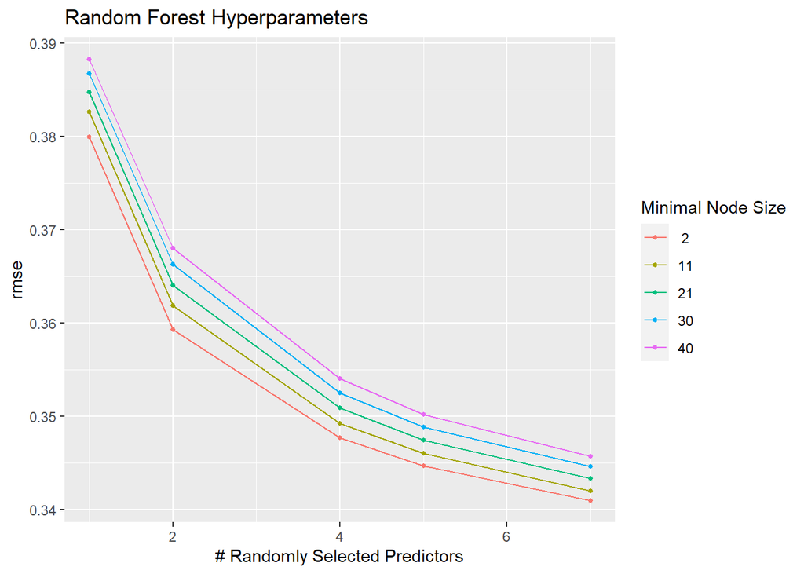

Figure 3: Random Forest Hyperparameters, Kitchen Sink

Now, let’s look at the ideal hyperparameters in Figure 4 for boosted tree, the next-best-performing model:

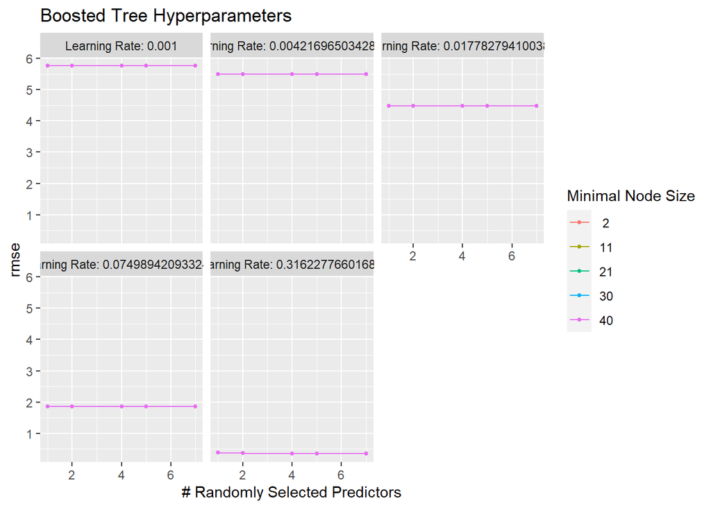

Figure 4: Boosted Tree Hyperparameters, Kitchen Sink

Given these lines are virtually flat and one color (where min_n = 40), it seems like learn_rate has a much stronger impact on the boosted tree model than the number of randomly sampled predictors and the minimal node size do. As that value goes up and edges closer upward, the RMSE goes down. It seems more impact that the previous trees have on the successive ones’ prediction/averaging leads to a better model (if that impact is slight, as the ideal .32 value indicates). For future tuning, I’d probably hone in on values between .2 and .5 to see if I’d get I’d get better results.

Now, here are the ideal hyperparameters for the elastic net model type in Figure 5:

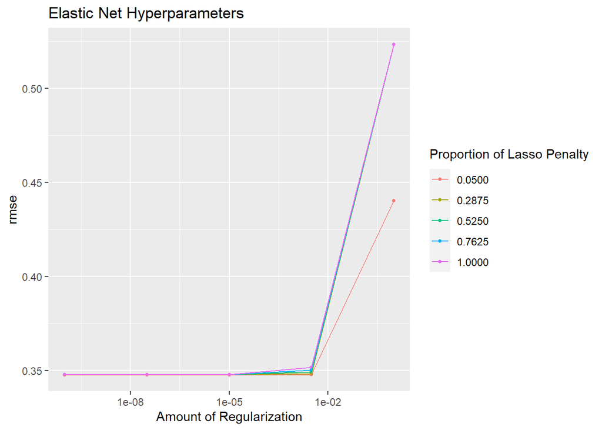

Figure 5: Elastic Net Hyperparameters, Feature-engineered

It appears that a lower amount of regularization is ideal, as the graph shoots up right before the penalty value hits .01. In fact, since the ideal amount of regularization is very close to 0 (1^-10), it indicates that a ridge regression model might be the best bet. The difference between mixtures, or proportions of lasso penalties, doesn’t appear to be as significant as the penalty with less regularization, though a lower one (.05) has the lowest RMSE with ideal regularization. As the penalty gets closer to 1, though, a lower proportion of lasso penalty has a lower RMSE. This makes sense, given a regularization value of 1 would indicate a full lasso model would be the way to go.

If I were to tune more, I’d likely exchange the elastic net model for a ridge one, given the ideal penalty is 0 for both the feature-engineered and kitchen sink models.

Finally, to wrap this up, let’s examine the best hyperparameters for the KNN model type in Figure 6:

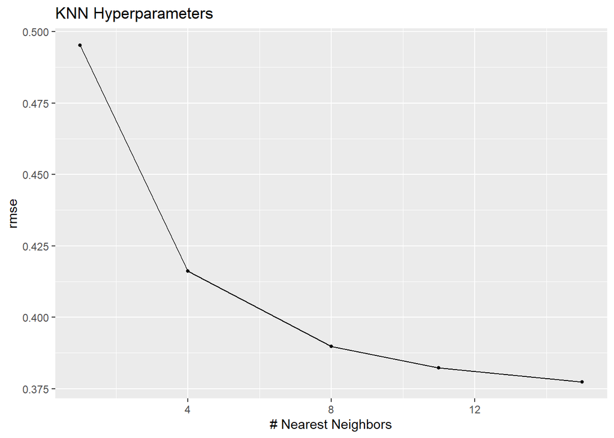

The more nearest neighbors there are, the lower the RMSE is. With the ideal range being 15 – the maximum – it seems like the more neighbors each data point has for the model to predict its values, the more accurate those predictions are.

As stated above, I will move forward with the random forest model that uses the kitchen sink recipe. It had the lowest RMSE at .341, and is multiple standard deviations away from the next-best model, the boosted tree one that uses the kitchen sink model. I’m not surprised that the tree models performed the best, though I’m a little surprised it wasn’t the feature-engineered ones, which finished in the middle of the pack. I thought the variables I eliminated – many of which were not correlated with salary at all – would eliminate noise, but that didn’t appear the case (though they weren’t too far off).

Autoplots for the other four models that were tuned but not included here can be found in the EDA Appendix.

## Final Model Analysis

After fitting the model to the testing data, Table 8 displays the random forest model’s new and final metrics:

Table 8: Random Forest (kitchen sink) Final Metrics

| Metric | Value |
| --- | --- |
| rmse | 0.3396268 |
| rsq | 0.5886811 |
| mae | 0.2485485 |

The mean RMSE went down when fitting to the testing data. I also displayed other metrics that might be more familiar. The R-squared value measures the correlation between the predicted and observed values while the MAE (or mean absolute error) signifies the average difference between the actual and predicted salaries regardless of direction.

Here, a mean RMSE of around .34 demonstrates that the predicted salaries fall about .34 log10 units away from the observed values, which is somewhat larger than I expected. It’d mean that, for instance, a player making $5 million in a season would, on average, have a predicted salary that’s almost $6 million off in the upper direction and $2 million off in the lower direction. The larger the number, the larger the difference is (which I’ll examine over a transformed scale back to the original scale).

Some easier values to digest are the R-squared value, which at .589, indicates a moderately strong relationship between the predicted and observed values. The mean absolute error, at about .249, indicates a .249-log10unit difference (smaller than the RMSE) between the observed and predicted values, which is moderate, but not massive.

Now, it’s time to compare the observed and predicted values – on the original scale – on a scatterplot in Figure 7.

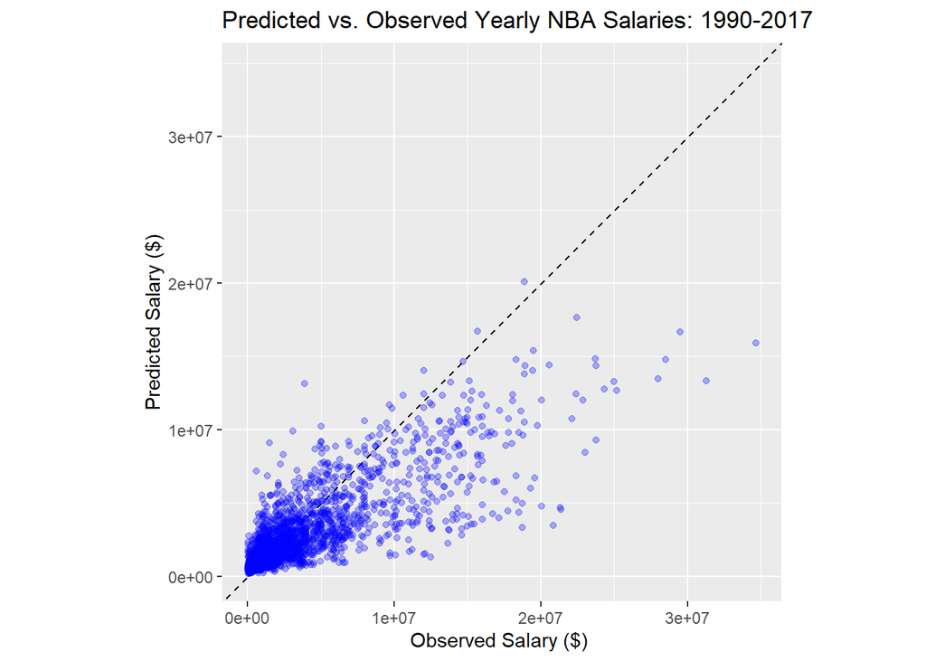

Figure 7: Observed vs. Predicted Salaries: Original Scale

It’s clear that as the salaries get past around $10 million, the model underestimates how much highly-paid players should be paid.

In some respects, that isn’t necessarily an indictment on the model itself. Since these salaries are yearly, and a number of contracts in the NBA are multi-year deals (take a sample of the top 100 contracts in the NBA in 2010, for example)[^2], there are a number of players who are overpaid and whose statistics don’t line up with their deserved values. That’s probably a factor in the larger error as the salaries increase.

<sup>2</sup> https://www.spotrac.com/nba/contracts/sort-value/all-time/start-2010/limit-100/

Zooming in, though, let’s look at how the model performed on those smaller contracts in Figure 8, where there appears to be a ton of data:

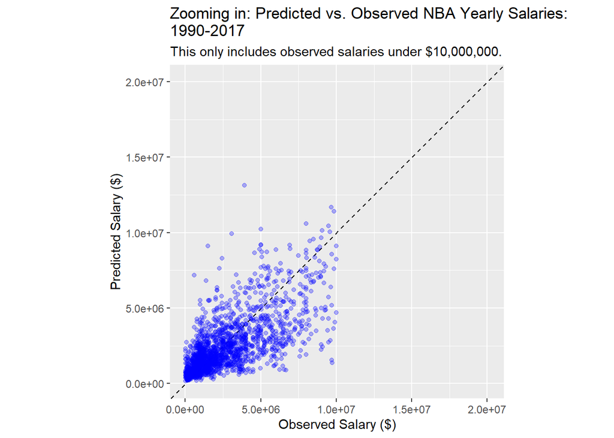

Figure 8: Observed vs. Predicted Salaries: Zooming into Smaller Contracts

The predictions appear to be much stronger here. On the whole, it’s a decent model that is moderately accurate when it comes to predicting salary, though it has lots of room to improve for larger salaries. I think it’s stronger than the others because of its ability to identify and weight interactions by itself without the human error (on my part) of removing variables that could’ve been meaningful in prediction (or vice versa: including too many variables that didn’t play a huge factor).

Though it isn’t perfect, building a predictive model is definitely worthwhile because it at least moves the needle – just compare it to the null baseline model’s observed vs. predicted values in Figure 9, which simply go off of the mean:

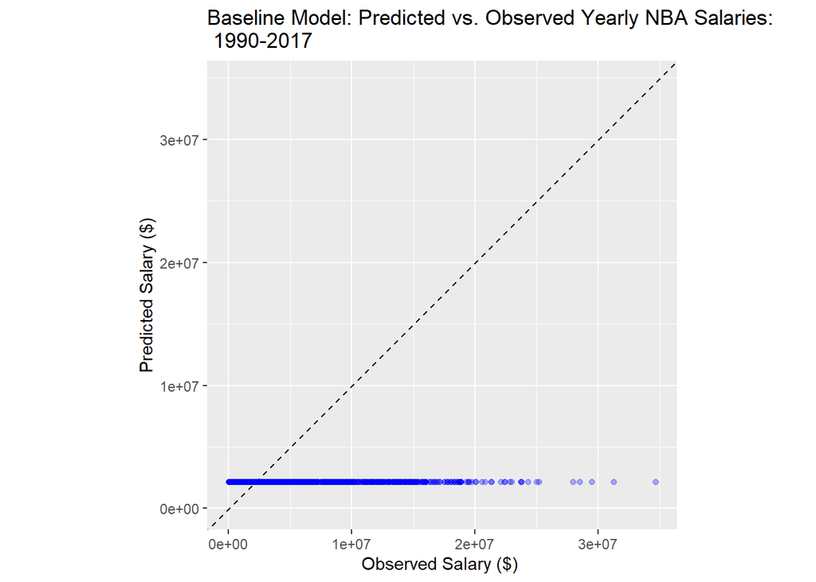

Figure 9: Observed vs. Predicted Salaries: Null Model

Clearly, simply going off of the mean (particularly in a sport where salaries constantly increase) isn’t a great way of predicting how much a player makes (or should make). Therefore, building the models and selecting a well-performing one is well-worthwhzile to explore this predictive question.

## Conclusion

Ultimately, I’ve concluded that based on statistical production, there are a number of highly-paid NBA players who might be overpaid in a given year relative to their actual output according to the model (or, speaking in terms of the model alone, that it’s difficult to predict higher salaries). It seems like tree-based kitchen sink models (in my case) function the best, though maybe turning the elastic net model into a ridge based on its ideal parameters could make those predictions especially strong, too.

In taking next steps, I’d love to examine the extra steps I added in each recipe to see which interactions, transformations, and splines were meaningful, and which weren’t. From there, I’d do another round of tuning based on the findings I made above, and I’d work to see if I could concretely designate different players as overpaid and underpaid given their circumstances and statistics. Do certain teams overpay more than others? To some underpay? Does it vary by position? How about by era? These are questions that would be awesome as jumping-off points to build off this model with.

## References (in order of footnotes)

Blanco, F. “NBA - Advanced & Basic Season Stats (1950-2017).” Kaggle. https://www.kaggle.com/datasets/whitefero/nba-players-advanced-season-stats-19782016.

“NBA Active Player Contracts, 2010.” Spotrac. https://www.spotrac.com/nba/contracts/sort-value/all-time/start-2010/limit-100/.

Associated Press (18 Feb 2010). “Nets to play two years in Newark.” ESPN.com. https://www.espn.com/nba/news/story?id=4925915.

chamrochinski (20 May 2014). “Charlotte Hornets Name Returns to Carolinas.” NBA.com. https://www.nba.com/hornets/charlotte-hornets-name-returns-carolinas.

The Sports XChange (24 January 2013). “New Orleans officially changes its nickname to Pelicans next season.” Yahoo Sports. https://sports.yahoo.com/news/orleans-officially-changes-nickname-pelicans-233005547–nba.html.

Michel, Riley (2 July 2019). “On this day: The Seattle SuperSonics officially move to Oklahoma City in 2008.” KIRO 7. https://www.kiro7.com/sports/on-this-date-9-years-ago-the-seattle-sonics-moved-to-oklahoma-city/547725919/.

“NBA Timeline and Abbreviatons.” SHRP Sports. https://www.shrpsports.com/nba/explain.htm.

Quinn, Sam (3 April 2023). “NBA CBA 101: Everything to know about new agreement, from salary cap to free agency and beyond.” CBS Sports. https://www.cbssports.com/nba/news/nba-cba-101-everything-to-know-about-new-agreement-from-salary-cap-to-free-agency-and-beyond/.

Bouranis, Yiannis (3 October 2023). “Top 5 biggest contracts in Spurs history ft Tim Duncan, Kawhi Leonard & more.” Sportskeeda. https://www.sportskeeda.com/basketball/top-5-biggest-contracts-spurs-history-ft-tim-duncan-kawhi-leonard.

## Appendix: EDA

To conduct this EDA, I utilized 50% of my training data for the cleaned dataset (4,339 observations). I used a split lower than the 80-20 training/testing one because I didn’t want to explore too much of my training set before running the recipes and conducting the tuning and fitting.

### Exploring Categorical Variable Distribution

I had two categorical variables to explore – position and team – in addition to each season year, which I factored and cut into bins through the recipe. I explored the univariate distributions of the first two in Table 4 and Table 5, but let’s look at each in relation to the target variable.

#### Position

Figure 10 displays the relationship between position and log10-transformed salary:

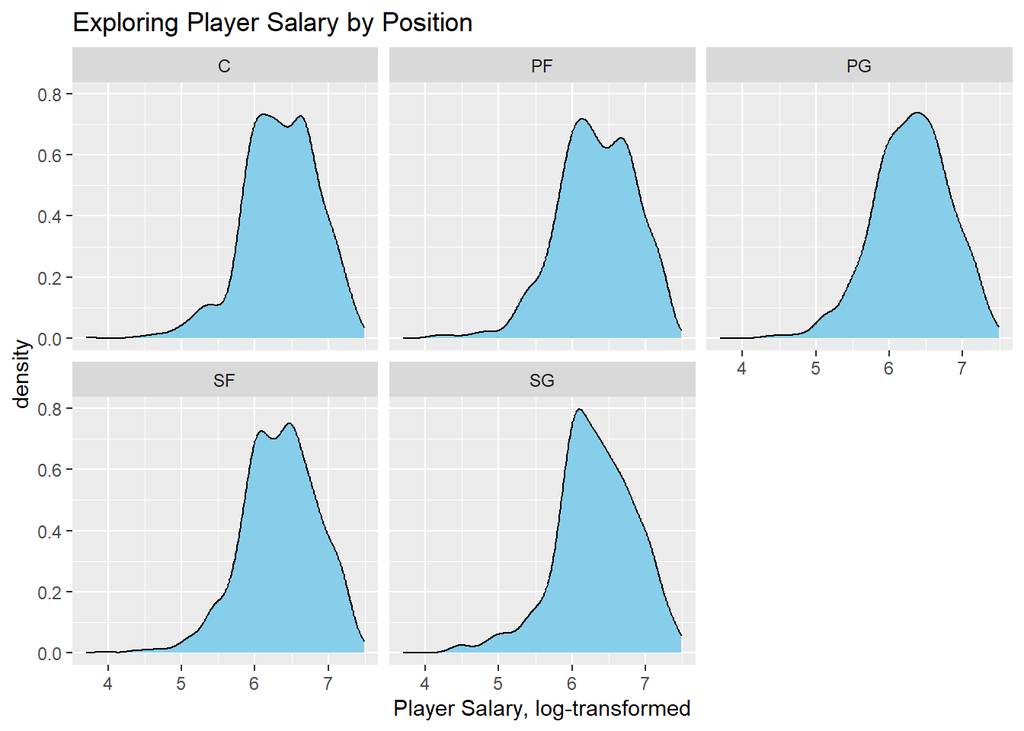

Figure 10: Exploring Player Salary by Position

#### Team

Figure 11 does the same for different teams:

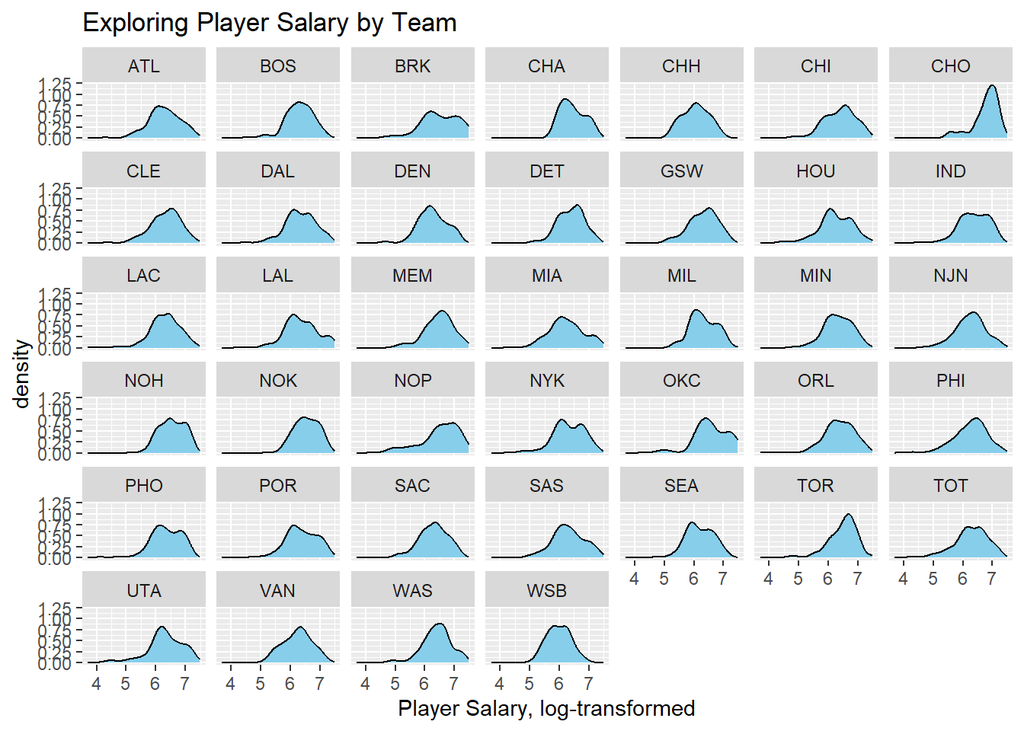

Figure 11: Exploring Player Salary by Team

Most teams that have been around for two decades-plus have relatively similar distributions. The ones with irregular ones haven’t been around with their names and locations as long: Brooklyn (BRK, entered the league in 2010s)[^3], CHO[^4], NOP[^5], OKC[^6], as well as NOK and WSB[^7].

<sup>3</sup> https://www.espn.com/nba/news/story?id=4925915

<sup>4</sup> https://www.nba.com/hornets/charlotte-hornets-name-returns-carolinas

<sup>5</sup> https://sports.yahoo.com/news/orleans-officially-changes-nickname-pelicans-233005547–nba.html

<sup>6</sup> https://www.kiro7.com/sports/on-this-date-9-years-ago-the-seattle-sonics-moved-to-oklahoma-city/547725919/

<sup>7</sup> https://www.shrpsports.com/nba/explain.htm

There isn’t significant variance among most of these teams, hinting that certain team types may not an especially significant role in predicting salary.

That’s partially why I decided **not to include team type** in my feature-engineered recipes. That, as well as the lack of balance and its inability to withstand a near-zero variance filter, indicated that I should remove it in that case.

However, the main reason why I decided to do so was because of the NBA’s salary cap. Unlike other sports – like baseball, where teams in larger markets that generate more revenue can pay its players more money – the NBA has a hard salary cap with maximum deals[^8] that’s dependent on how much revenue the league (not the teams themselves) generate. While there is a luxury tax, which gives richer teams some freedom to spend a little more, it’s fairly easy for small-market teams to retain superstars they develop on large deals.

<sup>8</sup> https://www.cbssports.com/nba/news/nba-cba-101-everything-to-know-about-new-agreement-from-salary-cap-to-free-agency-and-beyond/

Just look at the contracts for Tim Duncan, a Hall-of-Famer for the San Antonio Spurs[^9]. He stayed with the small-market team his entire career despite being an all-time great player largely because other teams could only match (not exceed) the max contract that the Spurs offered him.

<sup>9</sup> https://www.sportskeeda.com/basketball/top-5-biggest-contracts-spurs-history-ft-tim-duncan-kawhi-leonard#:~:text=%231%2C%20Tim%20Duncan%20(seven,league%20and%20San%20Antonio%20history.

That structure allows for parity in team success, which prevents one or two teams from completely wrecking the scale by offering players significantly more money than everyone else. Thus, a franchise (not team success) doesn’t have an especially strong effect on widely-varying salary distributions. With all of those factors in mind, I thought taking team out of the feature-engineered recipe was the right call. However, were I to explore this question more, I’d examine the effect of leaving the team variable in the model, dummying the variable, and taking out a near-zero variance filter.

#### Season Start

Let’s look at the distribution of salary by season in Figure 12:

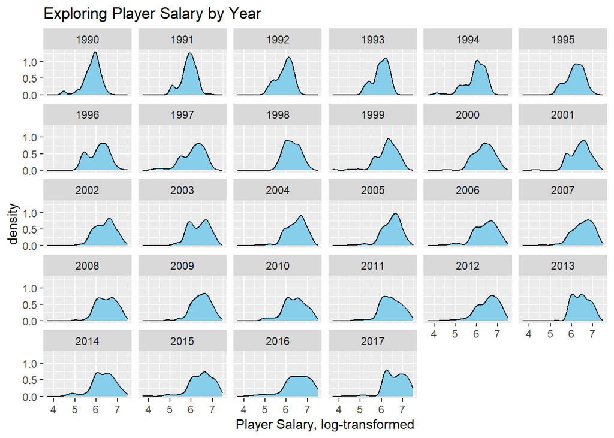

Figure 12: Exploring Player Salary by Year

This is mostly due to the way the NBA salary cap has skyrocketed in the last 30 years. It went from a little over $11 million in 1990 to over $99 million in 2017.[^10]. Consequently, teams had more money to spend on paying players.

<sup>10</sup> https://www.spotrac.com/nba/cba/

This is why I factored this originally numeric variable in my feature-engineered recipes, and cut the 28 seasons up into bin ranges of five years apiece. I wanted to account for a higher salary cap; a player averaging MVP-worthy numbers in 1990 did not command the same salary that an established superstar did in 2017.

Now, let’s dive into numeric variable transformations and distributions:

### Exploring Numeric Variable Distributions

In searching for transformations, I examined a slew of almost 50 numeric variables to examine their distributions and relationships with log10-transformed salary. Here, I’ll justify the ones that I ultimately did transform.

Those are: assist percent, field goals, field goals attempted, three-pointers made, three-pointers attempted, two-pointers made and attempted, offensive/defensive/total win shares, VORP, PER, three-point percentage, free throw percentage, blocks, free throws made and attempted, steals, points, and total/offensive/defensive rebounds.

#### Assist percent

Figure 13 displays the relationship between assist percentage and log-transformed salary.

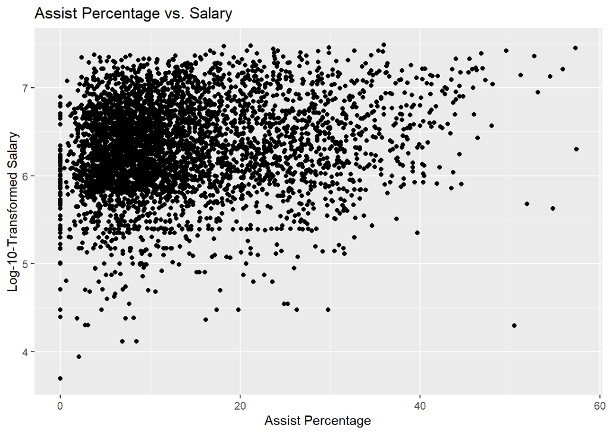

Figure 13: Assist Percentage vs. Log-Transformed Salary

There’s a clear right skew here; that’s what prompted me to apply a square-root transformation, which looks much more normal as displayed in Figure 14. It’s not perfect, but much better, and applying a log transforming creates a left skew:

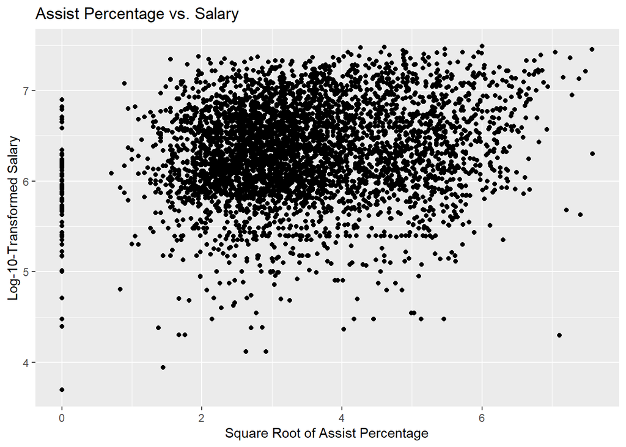

Figure 14: Square root of Assist Percentage vs. Log-Transformed Salary

For good measure, Figure 15 shows the univariate distribution of this transformed variable:

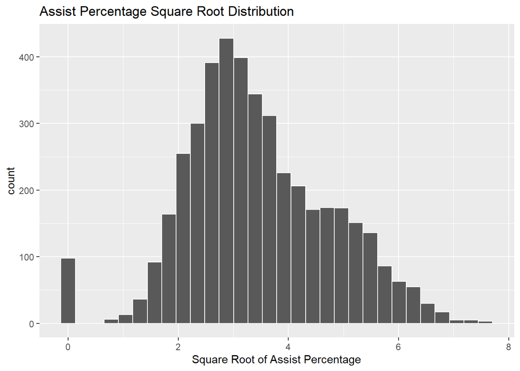

Figure 15: Square root of Assist Percentage Distribution

I followed this same process with most of the square-root transformed variables. Each of the following sections compares their univariate relationships, before and after transforming:

#### Field Goals Made

Figure 16 displays the untransformed distribution, while Figure 17 is the distribution after applying a square-root transformation:

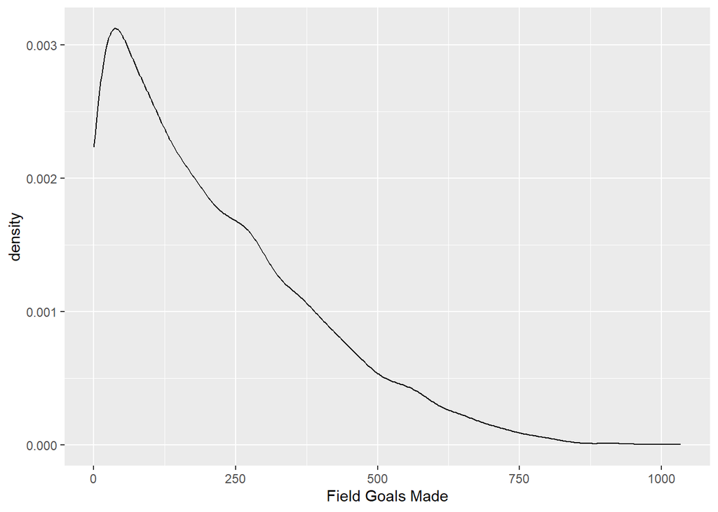

Figure 16: Field Goals Made Distribution

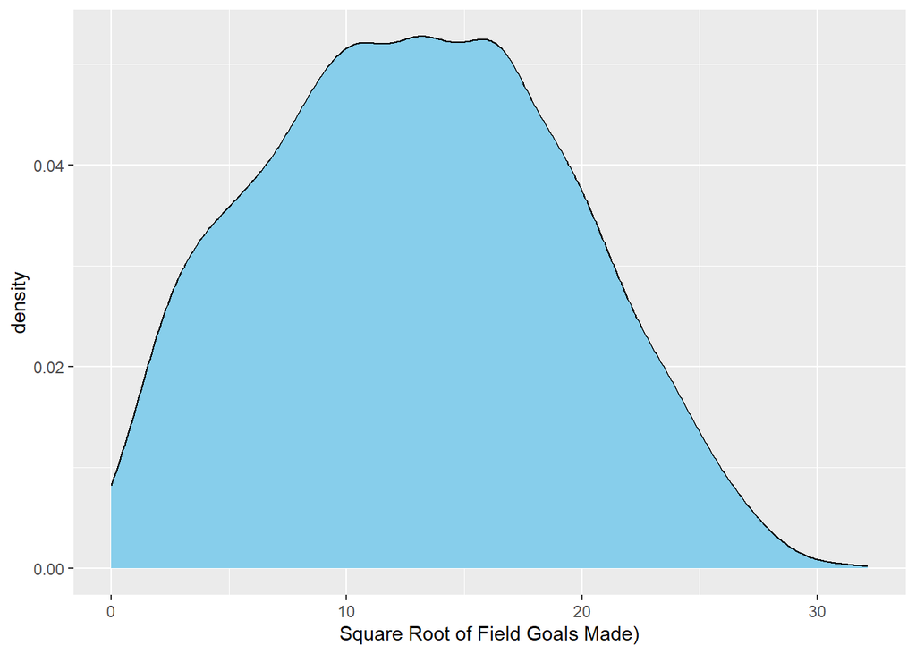

Figure 17: Field Goals Made Distribution (Square-Root Transformed

#### Field Goals Attempted

Figure 18 displays the untransformed distribution, while Figure 19 is the distribution after applying a square-root transformation:

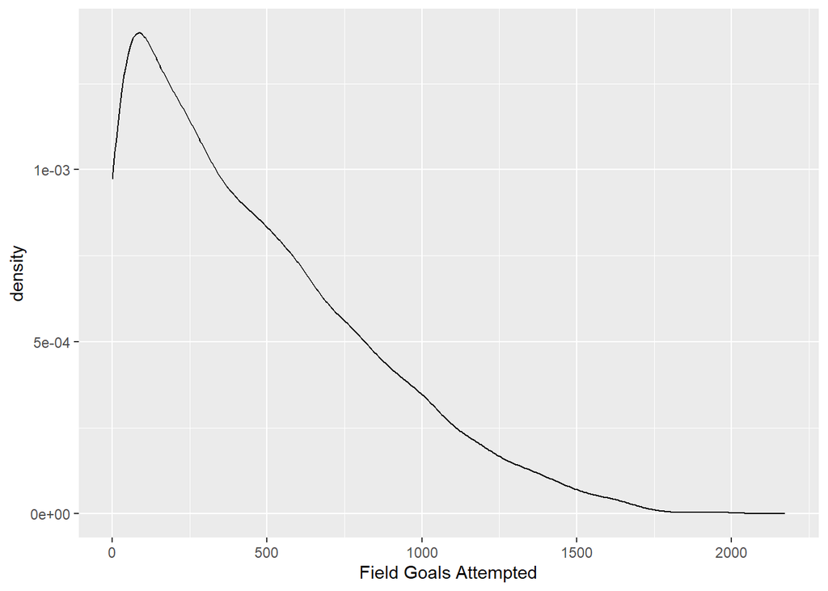

Figure 18: Field Goals Attempted Distribution

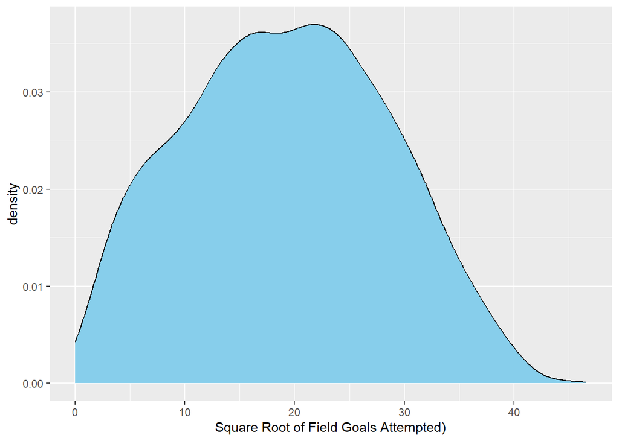

Figure 19: Field Goals Attempted Distribution (Square-Root Transformed)

This is almost the exact same distribution, which makes sense given total makes at least slightly increase as attempts increase. To make this as concise as I can, for makes and attempts, I’ll show the distribution for one:

#### Two-pointers made and attempted

Figure 20 shows the untransformed distribution for two-pointers made, while Figure 21 shows the distribution after the variable’s transformed. Two-point attempts follow the same pattern.

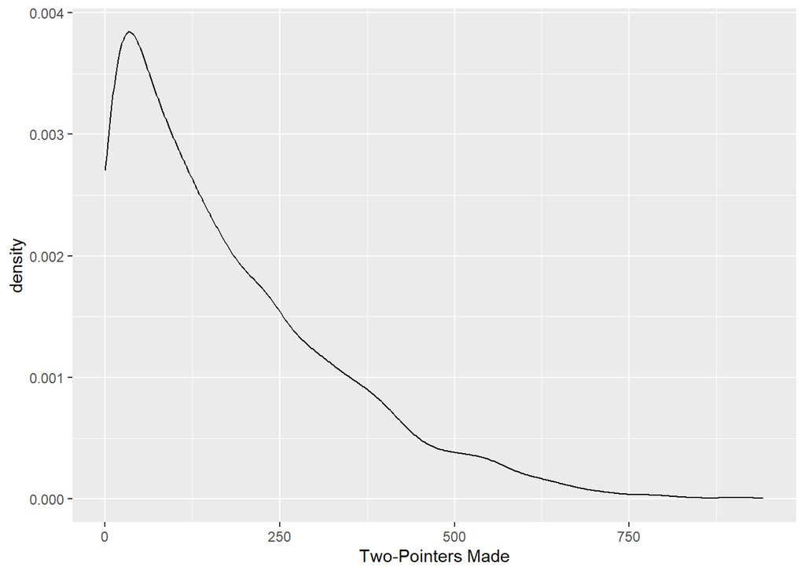

Figure 20: Two-pointers Distribution

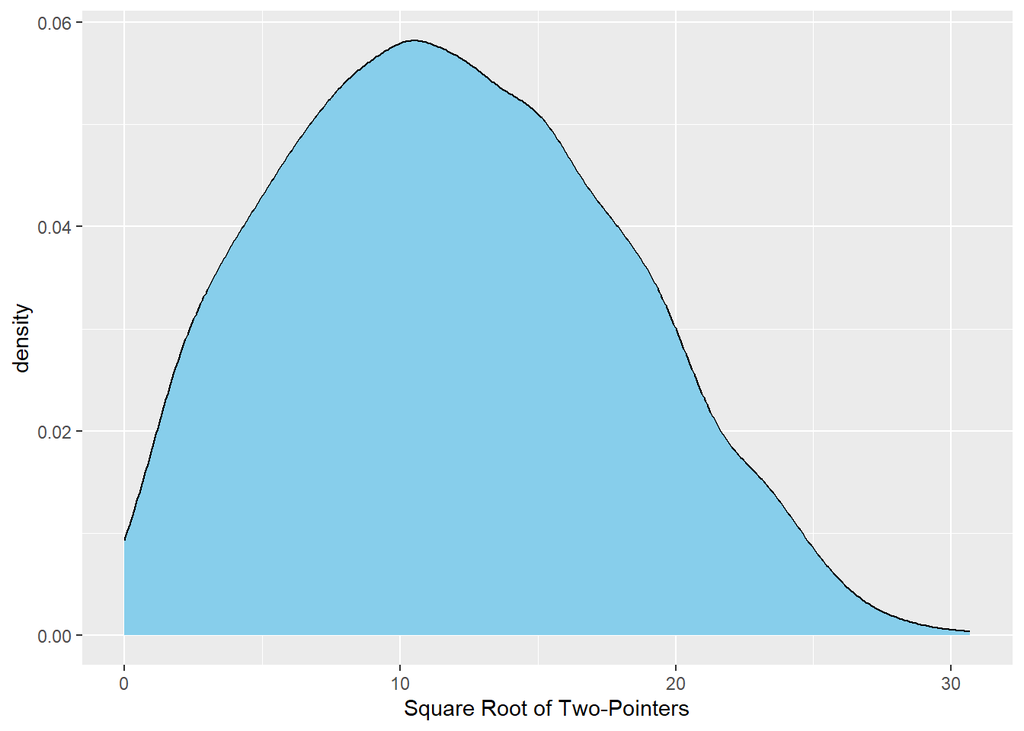

Figure 21: Two-Pointers Distribution (Square-Root Transformed)

#### Free throws attempted and made

Figure 22 shows the untransformed distribution for free throws made, while Figure 23 shows the distribution after the variable’s transformed. Free throw attempts follow the same pattern.

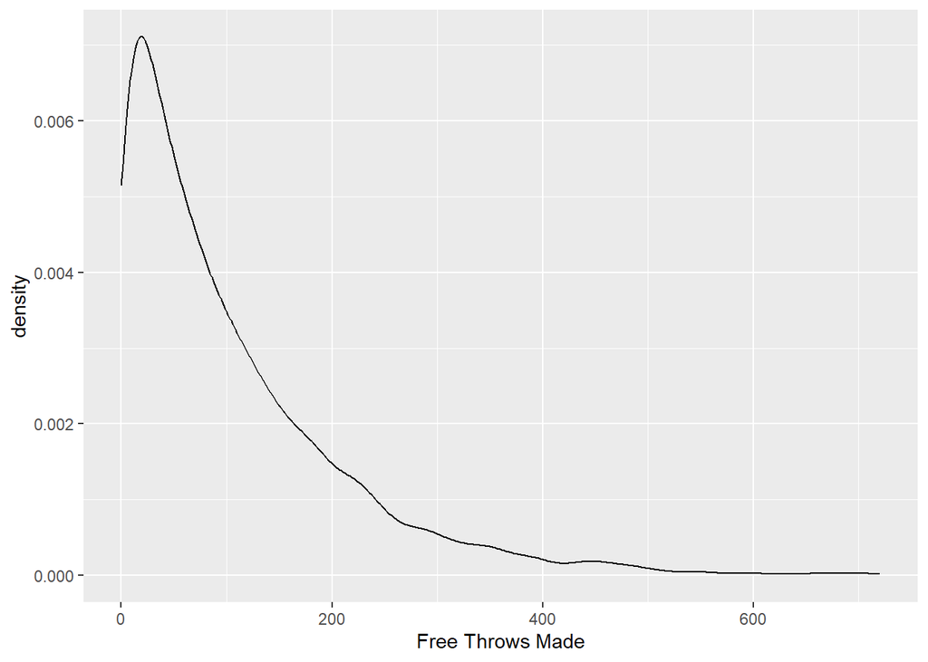

Figure 22: Free throws Distribution

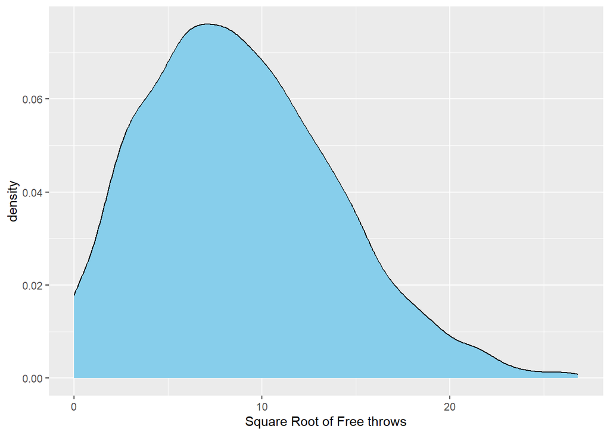

Figure 23: Free throws Distribution (Square-Root Transformed)

#### Steals

Figure 24 shows the untransformed distribution for steals, while Figure 25 shows the distribution after the variable’s transformed.

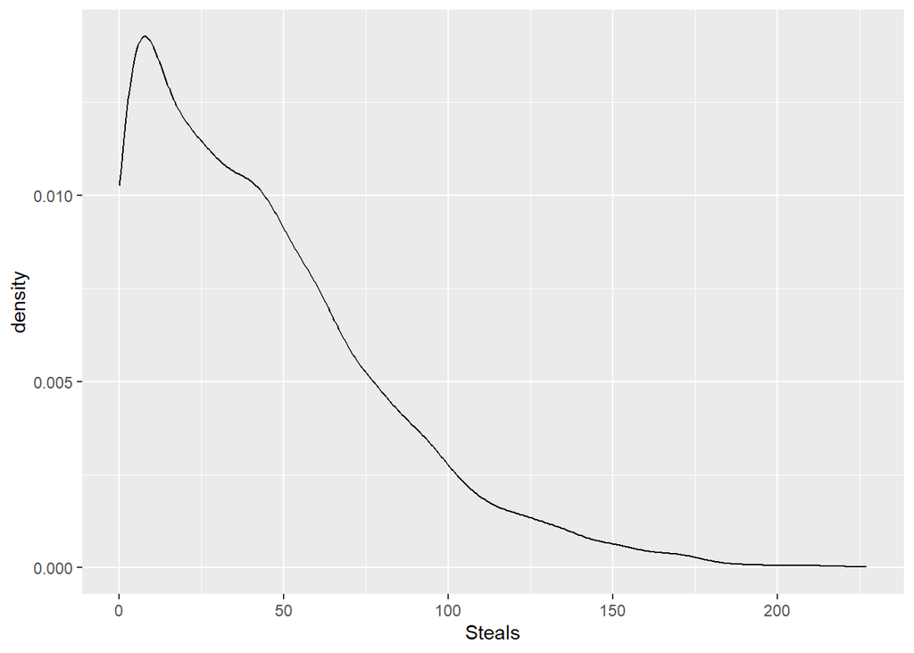

Figure 24: Steals Distribution

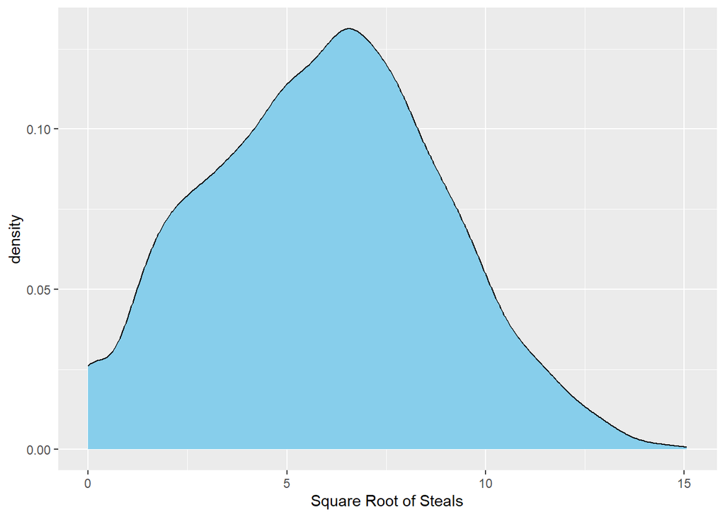

Figure 25: Steals Distribution (Square-Root Transformed)

#### Points

Figure 26 shows the untransformed distribution for points, while Figure 27 shows the distribution after the variable’s transformed.

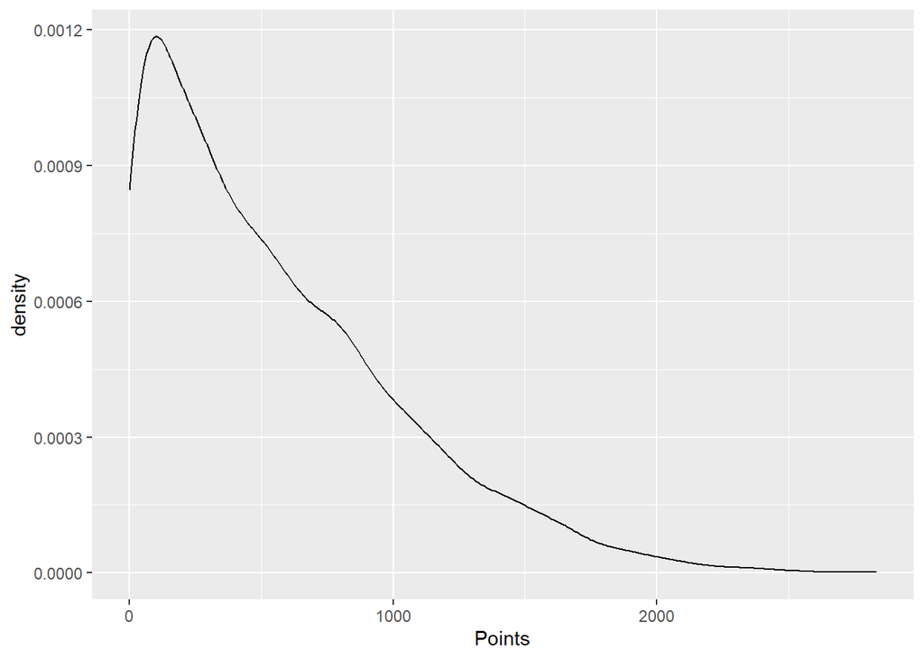

Figure 26: Points Distribution

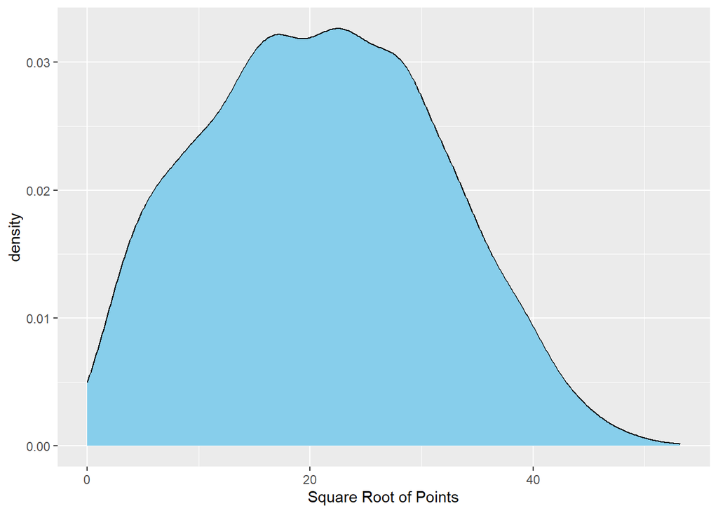

Figure 27: Points Distribution (Square-Root Transformed)

#### Total Rebounds

Figure 28 shows the untransformed distribution for total rebounds, while Figure 29 shows the distribution after the variable’s transformed.

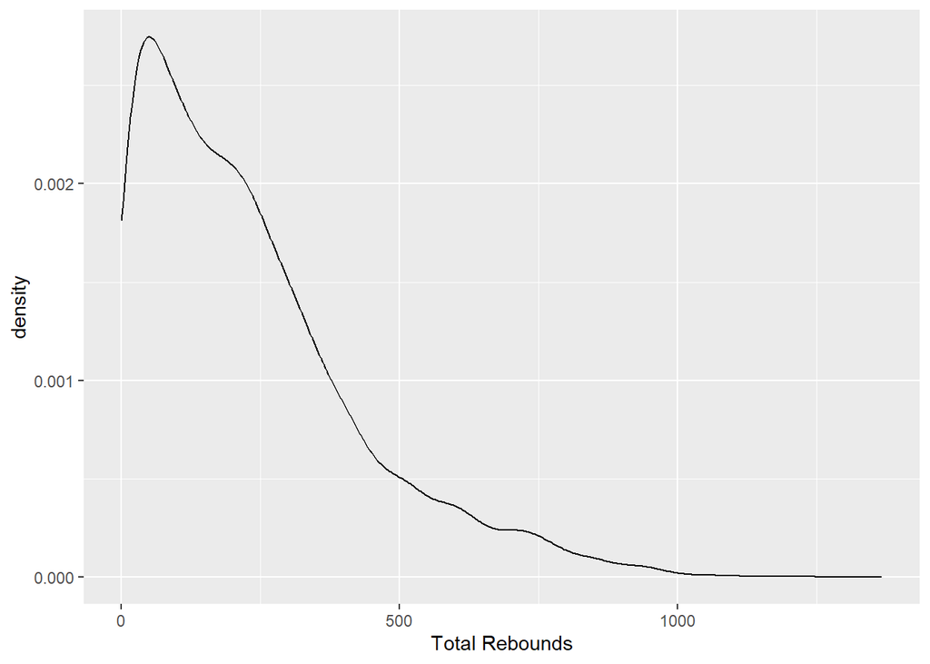

Figure 28: Total Rebounds Distribution

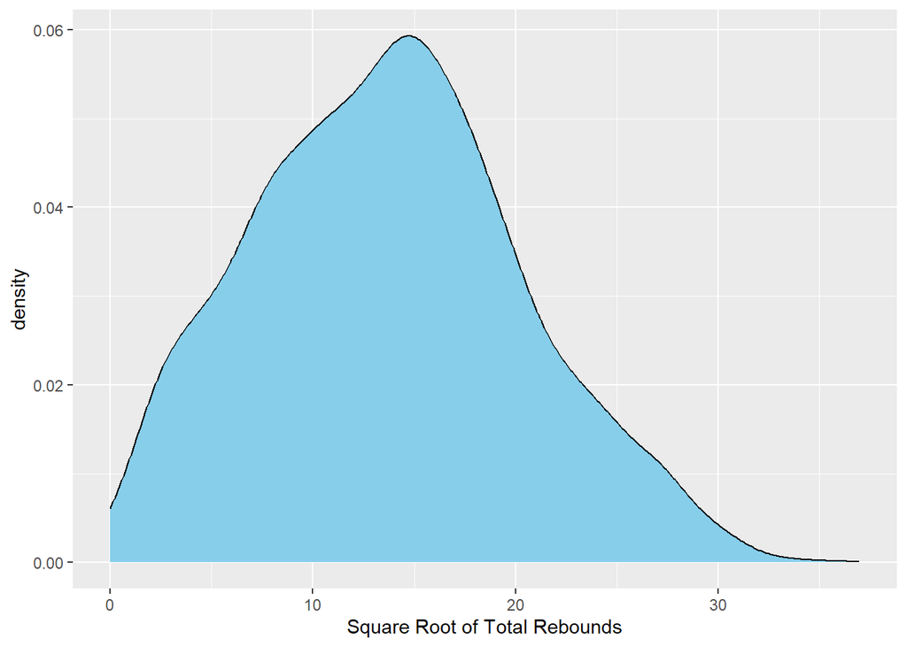

Figure 29: Total Rebounds Distribution (Square-Root Transformed)

#### Defensive Rebounds

Figure 30 shows the untransformed distribution for defensive rebounds, while Figure 31 shows the distribution after the variable’s transformed.

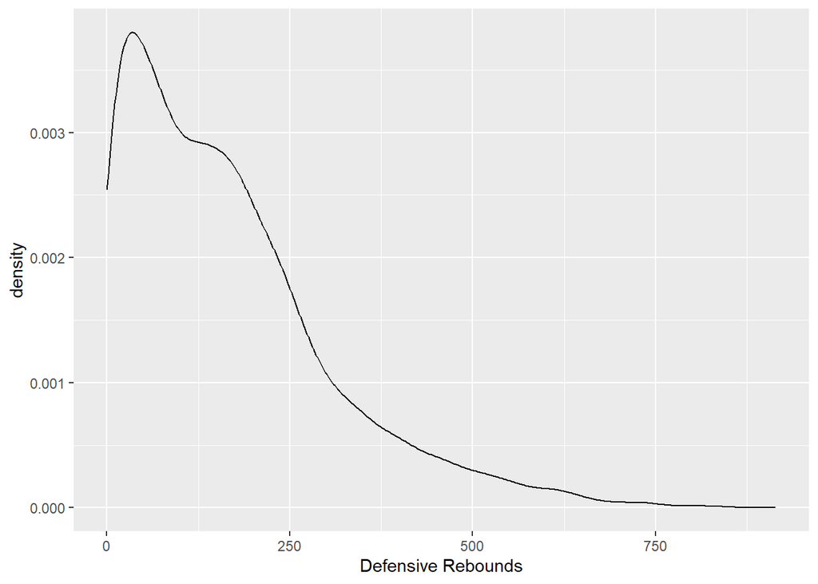

Figure 30: Defensive Rebounds Distribution

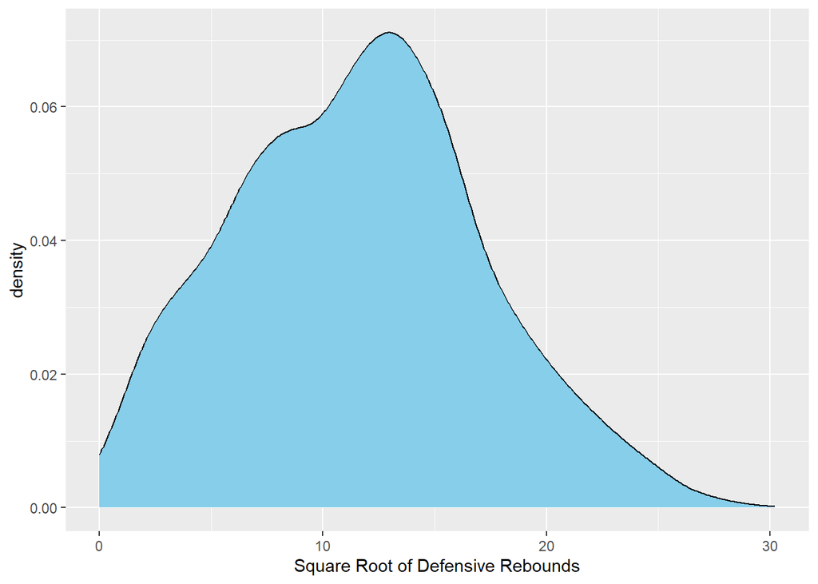

Figure 31: Defensive Rebounds Distribution (Square-Root Transformed)